# GQ - Report by Category

This page contains generalized (mostly averaged) data graphics. For a closer look at each specific day click [here](http://xpontimus.github.io/gqbydayhome.html).

# All the Graphs in One

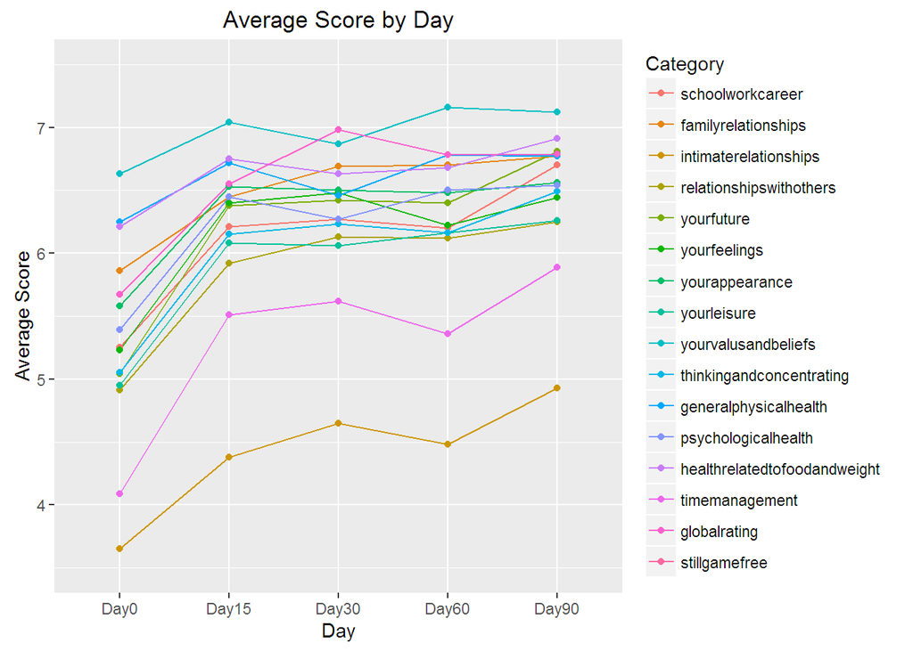

This is just all survey question lines on one graph. Good for looking at the big picture and identifying outliers. My interpretation is that most of this sample group struggles mostly with their time management and their intimate relationships. On the flipside, people were most confident throughout the program with their values and beliefs.

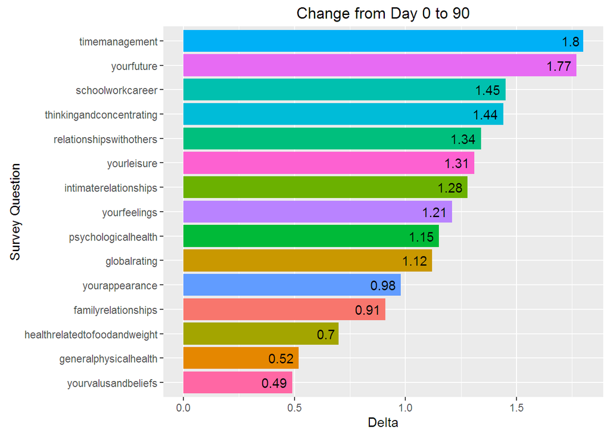

The graph above shows how much the average for that question has changed from Day 0 to Day 90. My interpretation is that in general, there was a large increase in confidence for time management and about their future. In general, the sample did not feel much had changed in general physical health our their values and beliefs.

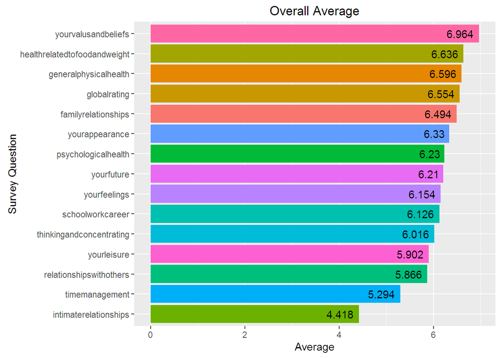

The graph above shows what people on average felt the best about throughout the entire program. In general, people felt the best about their values and beliefs, their health related to food and weight, and their general physical health. People felt the worst about their time management and intimate relationships.

# Isolated Graphs

Looking at all the survey question data plotted alone. You can use the legend from the very first graphic as a sort of table of contents.

### 0. Percent Relapsed

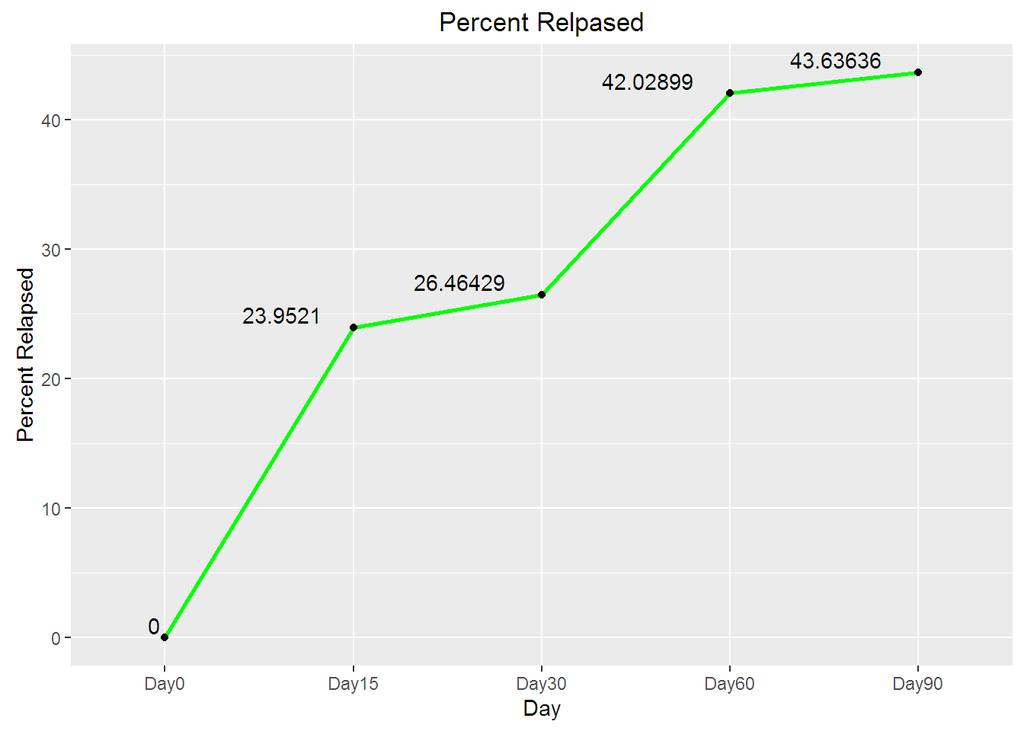

### 1. School/Work/Career

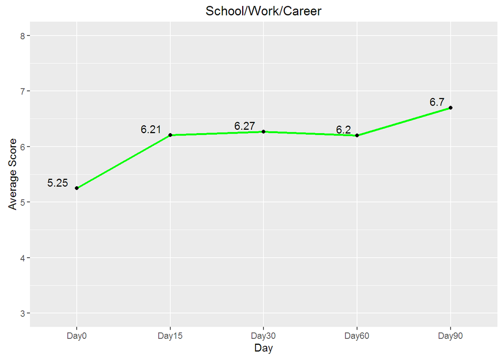

### 2. Family Relationships

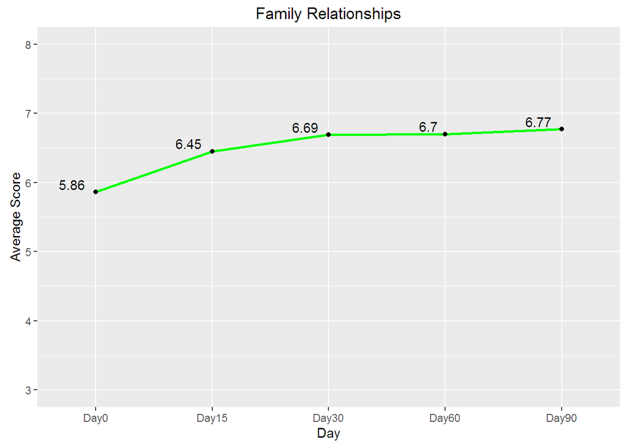

### 3. Intimate Relationships

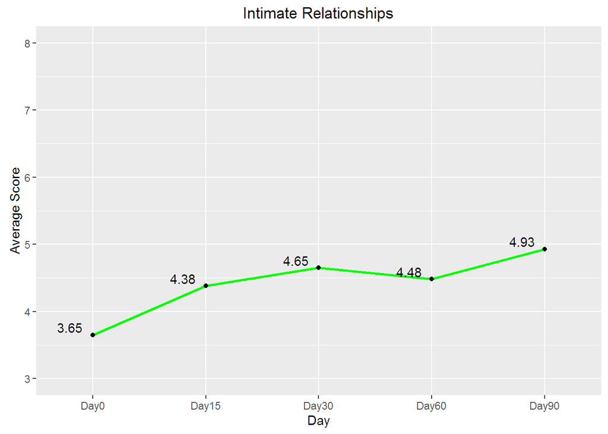

### 4. Relationships with Others

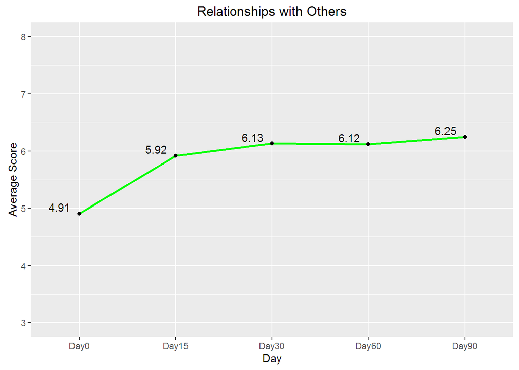

### 5. Your Future

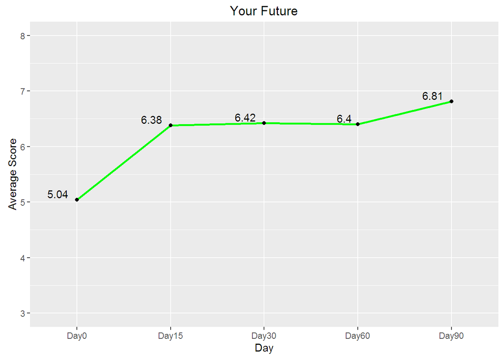

### 6. Your Feelings

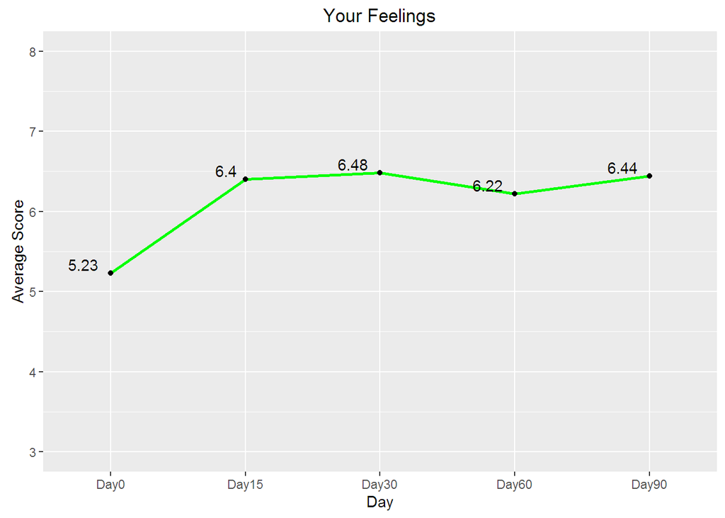

### 7. Your Appearance

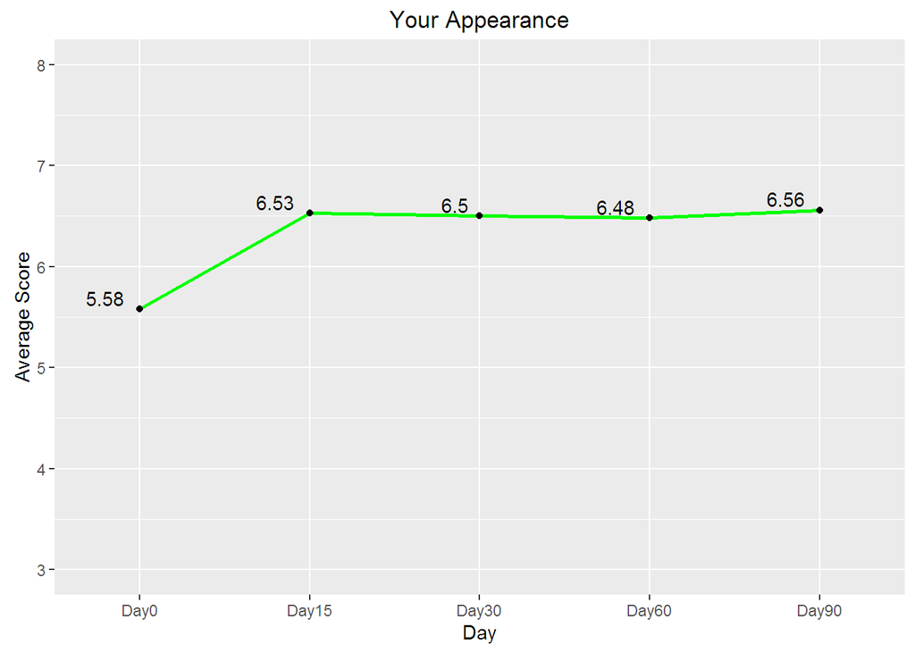

### 8. Your Leisure

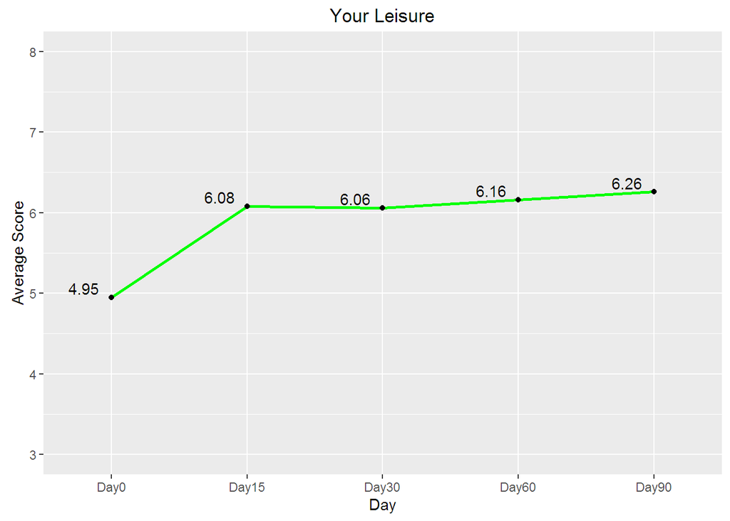

### 9. Your Values and Beliefs

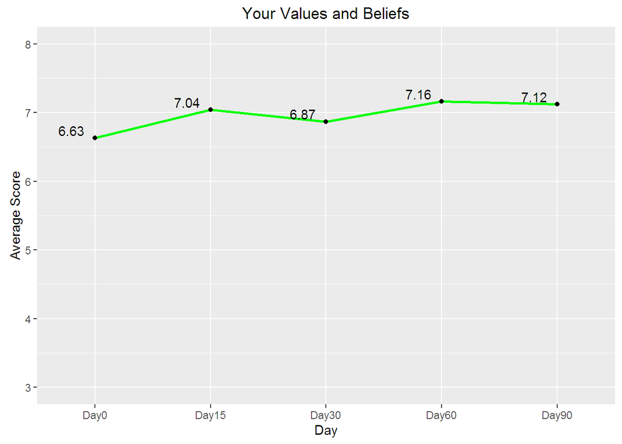

### 10. Thinking and Concentrating

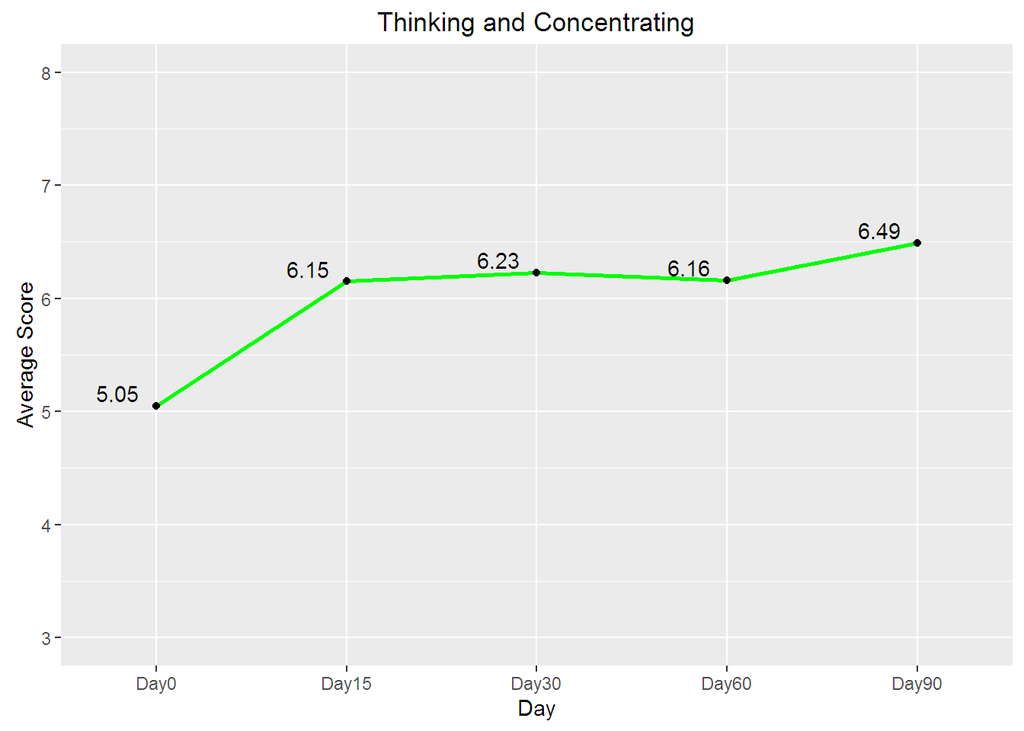

### 11. General Physical Health

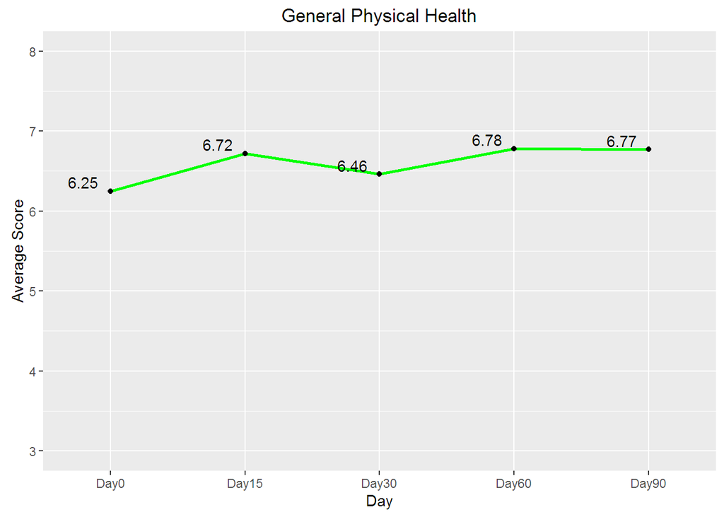

### 12. Psychological Health

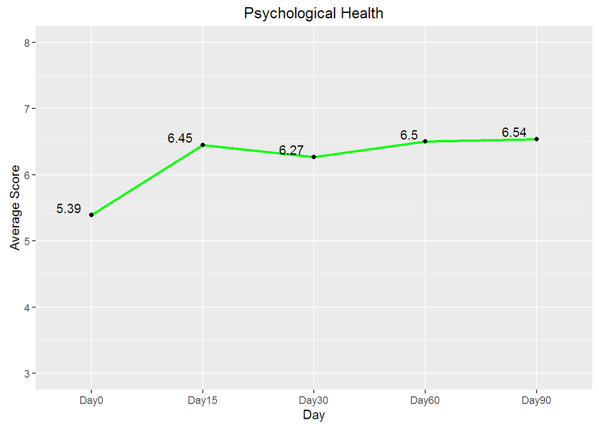

### 13. Health Related to Food and Weight

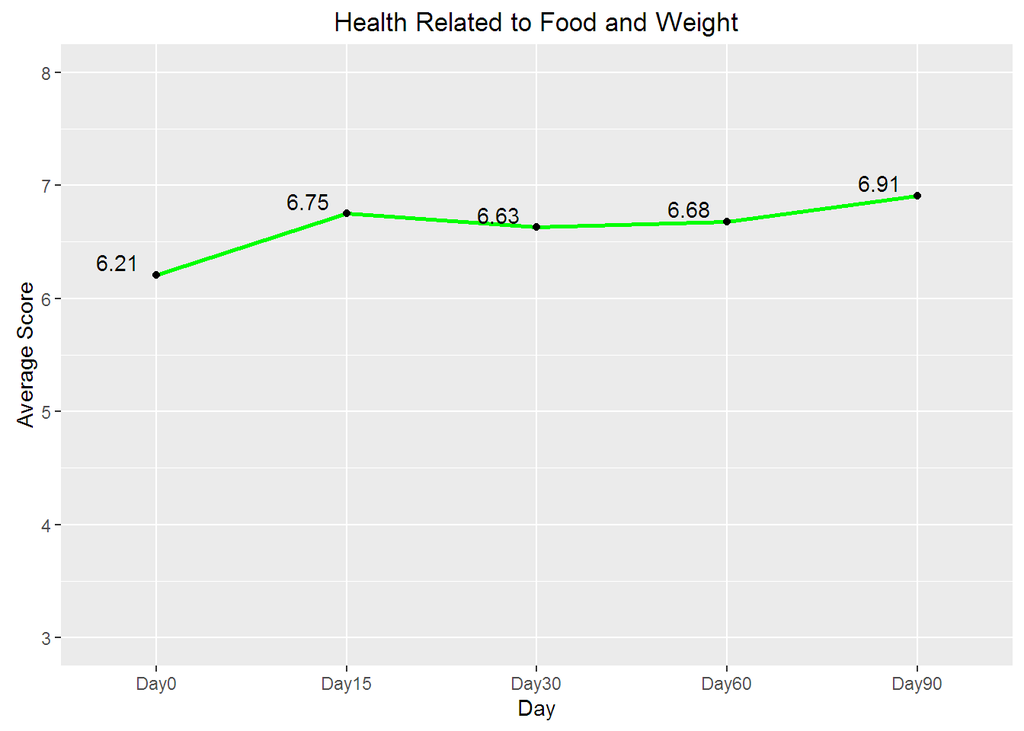

### 14. Time Management

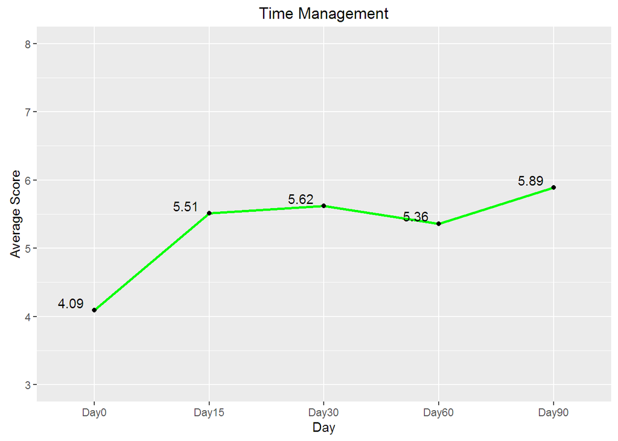

### 15. Global Rating

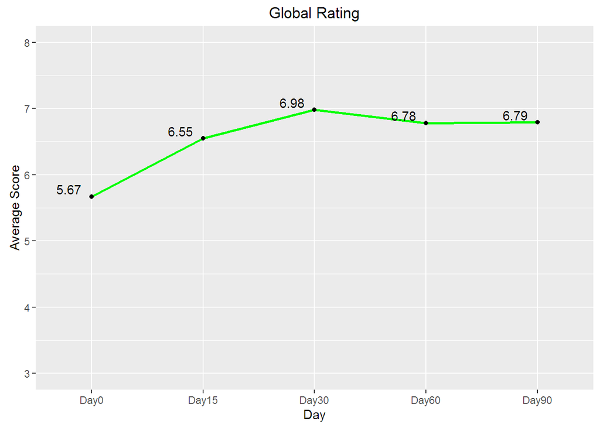